# Homework #2: Basic MC and Beyond

Ethan Ashby

We will need the following libraries for this homework.

```r
library(tidyverse)
library(readxl)
```

The following ensures that the same random choices are made each time the document is knit.

```r
set.seed(12345)
```

Instructions:

1. Be sure to put the file `homework-style.css` in the parent directory of the directory where you have your .Rmd file.
2. Put your solutions between the lines that read `:::: {.solution}` and `::::`.
3. Knit the file to .html.
4. Print the file to .pdf using a browser.
5. Upload your .pdf file to Gradescope.
6. After you upload to Gradescope, you will be asked to mark the pages your problem solutions are on.
7. Be sure to box your work with the `\boxed{put in box}` $\LaTeX$ command.
8. Be sure to give nonintegral answers to four significant digits (unless in $a \pm b$ form, in which case round up $b$ to two significant digits and truncate $a$ to the same number of decimal places as $b$.)

Suppose $U_1, \ldots, U_5$ are iid $\textsf{Unif}([0, 3])$. Estimate the probability that $U_1 U_2 \cdots U_5 < 0.02$ using basic Monte Carlo with 1000 samples. Report your result as $a \pm b$.

```r
set.seed(12345)
#basic MC simulation
dat<-replicate(1000, runif(5, min=0, max=3))

#this step takes the product of each column of 5 random uniform vbls
prods<-apply(dat, 2, prod)
#computes the basic MC estimate for P(U1*U2*U3*U4*U5)
mean(prods<0.02)
```

```
## [1] 0.042
```

```r
#compute SE of estimate
sd(prods<0.02)/sqrt(1000)
```

```
## [1] 0.006346359
```

The basic monte carlo estimate is $\boxed{0.0420 \pm 0.0064}$.

Suppose $U_1, \ldots, U_5$ are iid $\textsf{Unif}([0, 3])$.

1. Estimate the probability that $U_1 U_2 \cdots U_5 < 0.02$ using GBAS with $k = 1000$.
2. What is the chance that the output has greater than 10% absolute relative error?

```r
set.seed(12345)
#write gbas parent function
gbas <- function(k, coin) {
  total <- 0
  n <- 0
  while (total < k) {
    total <- total + coin()
    n <- n + 1 }
return((k - 1) / rgamma(1, n, 1))
}

#write coin function
f_coin <- function() {
  U_s<-runif(5, min=0, max=3)
  return(as.integer(prod(U_s) < 0.02))
}

gbas_pred<-gbas(k=1000, coin=f_coin)
gbas_pred
```

```
## [1] 0.04288881
```

My GBAS predicted probability is $\boxed{0.04289}$

2. Recall that for $\epsilon>0$ and $k$ a positive integer, the output of GBAS is an $(\epsilon, \delta)$-ras, where
   $$\delta=1-(\operatorname{cdf}_X(1/(1-\epsilon))-\operatorname{cdf}_X(1/(1+\epsilon)))$$
   Where $X \sim \textrm{Gamma}(k,k-1)$.

```r
1-(pgamma(1/0.9, 1000, 999)-pgamma(1/1.1, 1000, 999))
```

```
## [1] 0.001786416
```

The probability that the output has greater than 10% absolute error is $\boxed{0.001786}$.

Suppose $(U_1, U_2, U_3, U_4)$ are iid standard uniforms. Then if the first two uniforms are used to form a point in $\mathbb{R}^2$, and the last two uniforms are used to form a point in $\mathbb{R}^2$, the distance between the two points is
$$d = \sqrt{(U_1 - U_3)^2 + (U_2 - U_4)^2}$$

1. Use 1000 samples with Basic Monte Carlo to estimate the probability that $d > 0.5$. Report your answer as $a \pm b$.
2. Use GBAS with $k = 1000$ to estimate the probability that $d > 0.5$.

```r
set.seed(12345)
#basic monte carlo
coords<-replicate(1000, runif(4, min=0, max=1))
foi<-function(vec){
  sqrt((vec[1]-vec[3])^2+(vec[2]-vec[4])^2)
}

dists<-apply(coords, MARGIN=2, FUN=foi)
#calculate probability of distance being greater than 0.5
mean(dists>0.5)
```

```
## [1] 0.503
```

```r
#SE
sd(dists>0.5)/sqrt(1000)
```

```
## [1] 0.01581902
```

The basic monte carlo estimate is $\boxed{0.503 \pm 0.016}$.

```r
set.seed(12345)
#write gbas parent function
gbas <- function(k, coin) {
  total <- 0
  n <- 0
  while (total < k) {
    total <- total + coin()
    n <- n + 1 }
return((k - 1) / rgamma(1, n, 1))
}

#write coin function
f_coin <- function() {
  U_s<-runif(4, min=0, max=1)
  return(as.integer(foi(U_s) > 0.5))
}

gbas_pred<-gbas(k=1000, coin=f_coin)
gbas_pred
```

```
## [1] 0.5243816
```

The GBAS prediction is $\boxed{0.5244}$.

By combining uniforms, it is possible to create joint distributions where the random variables are not independent. For instance, suppose $U_1, U_2$ are iid standard uniform random variables. Let
$$(V_1, V_2) = (U_1 + U_2, U_1 - U_2).$$

1. Estimate $\mathbb{P}(V_1 > 1.5)$ using Basic Monte Carlo with 1000 samples, just reporting the mean without error.
2. Estimate $\mathbb{P}(V_2 > 0.5)$ using Basic Monte Carlo with 1000 samples, just reporting the mean without error.
3. Estimate $\mathbb{P}(V_1 > 1.5, V_2 > 0.5)$ using Basic Monte Carlo with 1000 samples, just reporting the mean without error.
4. Based on your estimates, are $V_1$ and $V_2$ independent?

```r
set.seed(12345)
#basic MC
U_s<-replicate(1000, runif(2, 0, 1))
V1s<-apply(U_s, MARGIN=2, FUN=function(vec){vec[1]+vec[2]})
mean(V1s>1.5)
```

```
## [1] 0.159
```

The basic MC estimate of $\mathbb{P}(V_1 > 1.5)$ is $\boxed{0.1590}$

```r
set.seed(12345)
#basic MC
U_s<-replicate(1000, runif(2, 0, 1))
V2s<-apply(U_s, MARGIN=2, FUN=function(vec){vec[1]-vec[2]})
mean(V2s>0.5)
```

```
## [1] 0.117
```

The basic MC estimate of $\mathbb{P}(V_2 > 0.5)$ is $\boxed{0.1170}$

```r
set.seed(12345)
#basic MC
U_s<-replicate(1000, runif(2, 0, 1))
V1s<-apply(U_s, MARGIN=2, FUN=function(vec){vec[1]+vec[2]})
V2s<-apply(U_s, MARGIN=2, FUN=function(vec){vec[1]-vec[2]})
mean(V1s>1.5 & V2s>0.5)
```

```
## [1] 0
```

The basic MC estimate of $\mathbb{P}(V_1 > 1.5, V_2 > 0.5)$ is $\boxed{0}$.

If $V_1, V_2$ are independent, then $\mathbb{P}(V_1 > 1.5, V_2 > 0.5)$=$\mathbb{P}(V_1 > 1.5) \cdot \mathbb{P}(V_2 > 0.5)$. This is not true in this case, because $\mathbb{P}(V_1 > 1.5), \mathbb{P}(V_2 > 0.5)$ are nonzero while $\mathbb{P}(V_1 > 1.5, V_2 > 0.5)$ is 0. Thus, $V_1, V_2$ are NOT independent.

```r
#water_flow generates one random flow value
water_flow<-function(){
  r1<-runif(1, 50, 100)
  r2<-runif(1, 20, 30)
  r3<-runif(1, 40, 45)
  return(r1+r2+r3)
}

#calculate 100000 random flows
flows<-replicate(10^5, water_flow())

#basic MC estimate of the probability
mean(flows>115)
```

```
## [1] 0.99175
```

```r
sd(flows>115)/sqrt(10^5)
```

```
## [1] 0.0002860423
```

A key Monte-Carlo application in frequentist statistics is the estimation of the $p$-value of a particular data set. Given data modeled as $X$, and a statistic $S(X)$, the *$p$-value* of the particular realization of the data set $x$ is $\mathbb{P}(S(X) \geq S(x))$.

For example, suppose the following data is collected.

```r
x <- c(3.6, 1.8, 3.3, 2.3, 4.5, 2.9)
y <- c(79, 54, 74, 62, 85, 55)
```

(These are eruption times and times between eruptions for Old Faithful geyser in Yellowstone National Park.)

The `cor` function, for a set of $x$-coordinates and $y$-coordinates, returns a number between -1 and 1 that indicates how strongly correlated the $x$ and $y$ coordinates are.

Consider the `cor` statistic for the data above

```r
cor(x, y)
```

```
## [1] 0.8980788
```

That is a high correlation! But is it enough to disqualify a model where the $x$ values are iid $\textsf{N}(3.1, 1^2)$ and the $y$ values are iid $\textsf{N}(68.2, 13^2)$ and the $x$ and $y$ are independent?

Find the $p$-value of this model by drawing six $(x, y)$ pairs independently 1000 times to estimate the probability that the `cor` function returns a number greater than 0.8980788. Report the result as $a \pm b$.

```r
set.seed(12345)
#function that computes correlation between random draws from above distributions
cor_null<-function(){
  x_norms<-rnorm(6, mean=3.1, sd=1)
  y_norms<-rnorm(6, mean=68.2, sd=13)
  return(cor(x_norms, y_norms))
}

#replicate function call
correlations_under_null<-replicate(1000, cor_null())

mean(correlations_under_null>0.8980788)
```

```
## [1] 0.004
```

```r
sd(correlations_under_null>0.8980788)/sqrt(1000)
```

```
## [1] 0.001996995
```

The basic monte carlo estimate for this probability is $\boxed{0.0040 \pm 0.0020}$.

Find the smallest value of $k$ such that the output of `gbas(k, coin)` has at most a $10^{-6}$ chance of being more than 5% relative error away from the true answer.

Recall that for $\epsilon>0$ and $k$ a positive integer, the output of GBAS is an $(\epsilon, \delta)$-ras, where
$$\delta=1-(\operatorname{cdf}_X(1/(1-\epsilon))-\operatorname{cdf}_X(1/(1+\epsilon)))$$
Where $X \sim \textrm{Gamma}(k,k-1)$.

In this case $\epsilon=0.05$ and $\delta=10^{-6}$.

```r
#write function that computes probability of being more than 5% away from true answer
epsilon=0.05
delta=10^-6
foo<-function(k){1-(pgamma(1/(1-0.05), k, k-1)-pgamma(1/(1+0.05), k, k-1))}

#run function over a grid of k values and return first entry that is less than 10^-6
search_grid<-5000:10000
index=head(which(foo(search_grid)<10^-6), 1)

#return smallest k that satisfies
search_grid[index]
```

```
## [1] 9768
```

The smallest $k$ that satisifies this requirement is $\boxed{k=9768}$.

Suppose the goal is to draw $X$ with density
$$f_X(s) = \frac{3}{2}(s - 1)^2 \mathbb{I}(s \in [0, 2]).$$
Find a function $g$ such that for $U \sim \textsf{Unif}([0, 1])$, $g(U) \sim X$.

Step 1: find the $\operatorname{cdf}_X(x)$
$$\operatorname{cdf}_X(x)=\int^a_{-\infty} \frac{3}{2}(x - 1)^2 \mathbb{I}(x \in [0, 2])$$
Let’s calculate the cdf via integration wrt x. The cdf is:

$$\frac{1}{2}(x-1)^3 \ \ \ \ \ \ \ \ x \in [0,2] \\$$

Now solve $u=\operatorname{cdf}_X(a)$

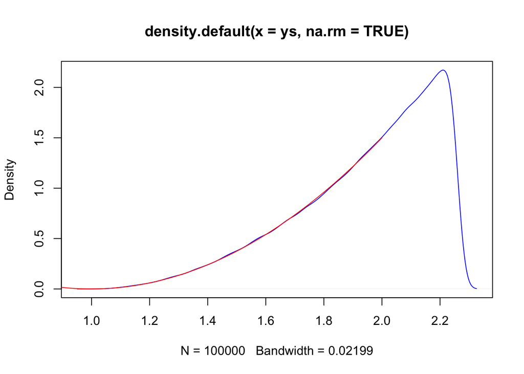

```r
xs<-runif(100000, min=0, max=1)
ys<-(2*xs)^(1/3) + 1

x<-seq(0, 2, by=0.01)
y<-1.5*(x-1)^2

density(ys, na.rm=TRUE) %>% plot(col="blue")
lines(x, y, col="red")
```

Suppose the goal is to sample $Y$, where
$$\mathbb{P}(Y = -1) = \mathbb{P}(Y = 0) = 0.2, \ \mathbb{P}(Y = 1) = \mathbb{P}(Y = 2) = 0.3.$$

Find a function $g$ such that for $U \sim \textsf{Unif}([0, 1])$, $g(U) \sim Y$.

Using the climbing bars method:

$$g(U)=-1 \cdot \mathbb{I}(U \in [0, 0.2)) + 0 \cdot \mathbb{I}(U \in [0.2, 0.4)) + 1 \cdot \mathbb{I}(U \in [0.4, 0.7)) + 2 \cdot \mathbb{I}(U \in [0.7, 1]) \\
\boxed{g(U)=-1 \cdot \mathbb{I}(U \in [0, 0.2)) + 1 \cdot \mathbb{I}(U \in [0.4, 0.7)) + 2 \cdot \mathbb{I}(U \in [0.7, 1])}$$

1. Find a function $g$ such that for $U \sim \textsf{Unif}([0, 1])$, $g(U)$ has density $f(s) = [0.5 - 0.1 s] \mathbb{I}(s \in [-1, 1])$.
2. Estimate $\mathbb{V}[X]$ using `var` with 1000 samples from density $f$.
3. Find $\mathbb{V}[X]$ analytically as a check that your $g$ function is working.
1. Given $f(s) = [0.5 - 0.1 s] \mathbb{I}(s \in [-1, 1])$, we need to first find the cdf. $F(s)=\int_{-1}^a 0.5-0.1s=[0.5s-0.05s^2]^a_{-1}=0.5a-0.05a^2 + 0.5 + 0.05=-0.05a^2+0.5a+0.55$

Now set $U$ equal to the cdf and and solve for $g$:
$$U=-0.05a^2+0.5a+0.55 \\
20U=-a^2+10a+11 \\
-20U=a^2-10a-11 \\
0=a^2-10a-11+20U \\
a=\frac{10 \pm \sqrt{100-4(-11+20U)}}{2}=5 \pm \sqrt{25+11-20U}=5 \pm \sqrt{36-20U}\\$$
Note: we choose the minus version $\boxed{g(U)=5 - \sqrt{36-20U}}$ because it is the only version of the answer that provides us with solutions between $[-1, 1]$.

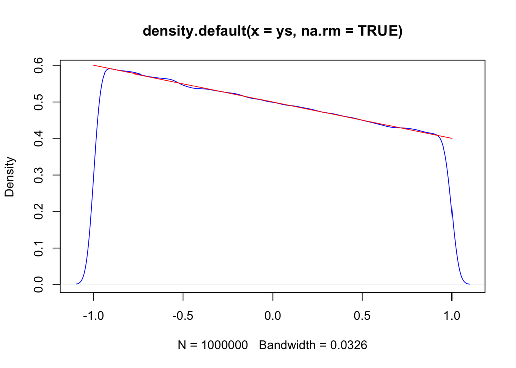

```r
set.seed(12345)
xs<-runif(1000000, min=0, max=1)
ys<-5-sqrt(36-20*xs)

x<-seq(-1, 1, by=0.01)
y<-0.5-0.1*x

density(ys, na.rm=TRUE) %>% plot(col="blue")
lines(x, y, col="red")
```

Validating the results empirically show that our function of the random uniform variables $g$ (shown in blue) generates data from our density of interest (red) over the desired interval!

```r
set.seed(12345)
xs<-runif(1000, min=0, max=1)
ys<-5-sqrt(36-20*xs)
var(ys)
```

```
## [1] 0.3192901
```

Our estimate of the variance is the variance of our randomly generated variables from our distribution: $\boxed{0.3193}$.

3. Recall our density is: $f_X(x) = [0.5 - 0.1 x] \mathbb{I}(x \in [-1, 1])$. It is known that: $\mathbb{V}[X]=E[X^2]-E[X]^2$ $\mathbb{V}[X]=E[(X-E[X])^2]$. $E[X]=\int_{-\infty}^{+\infty} x f_x(x) dx = \int_{-1}^{+1} x (0.5-0.1x) dx= -\frac{1}{15}$ $\mathbb{V}[X]=E[(X-E[X])^2]=\int_{-\infty}^{+\infty} (x-E[X])^2 f_X(x)dx= \int_{-1}^{1} (x+\frac{1}{15})^2 (0.5 - 0.1 x) dx= \frac{74}{225} \approx \boxed{0.3289}$.

Thus, our empirical estimate of the variance ($0.3193$) is quite close to the analytical variance ($0.3289$). Our solution works!